```python
from IPython.display import HTML

HTML('''<script>
code_show=true;
function code_toggle() {
 if (code_show){
 $('div.input').hide();
 } else {
 $('div.input').show();
 }
 code_show = !code_show
}
$( document ).ready(code_toggle);
</script>
<form action="javascript:code_toggle()"><input type="submit" value="Click here to toggle on/off the raw code."></form>''')
```

# Zimbabwe Enterprise Survey

This notebook looks at key survey findings from the 2016 World Bank Enterprise Surveys conducted in Zimbabwe.

- Data source: https://www.enterprisesurveys.org/Data/
- Time frame: 2016

In this notebook I simply look at key findings by region. The World Bank has the larger report at https://www.enterprisesurveys.org/data/exploreeconomies/2016/zimbabwe#informality

```python
%matplotlib inline
import seaborn as sns
import matplotlib.pyplot as plt
import pandas as pd
import numpy as np
import ipystata
import statsmodels.formula.api as smf
```

### Summary Statistics

```python
pd.set_option('display.float_format', lambda x: '%.2f' % x)
```

```python
zim_df.columns.tolist()
```

```python
df = zim_df[['industry', 'region', 'obstacle', 'finance',
 'informality']]
```

The figures below show the distribution of the companies surveyed by region and industry:

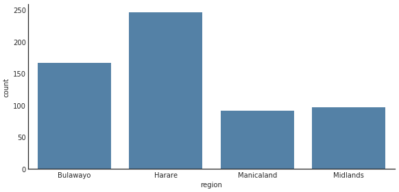

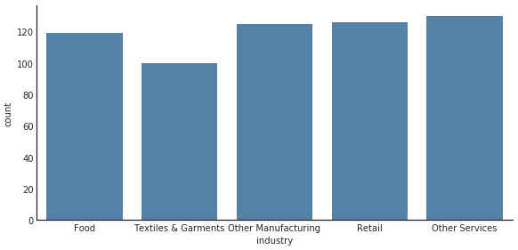

```python
with sns.axes_style('white'):
    g = sns.factorplot("region", data=zim_df, aspect=2,
                       kind="count", color='steelblue')

with sns.axes_style('white'):
    g = sns.factorplot("industry", data=zim_df, aspect=2,
                       kind="count", color='steelblue')
```

- Overall, about 96% of sales are within Zimbabwe, ~4% are exported (primarily indirectly, i.e., through selling to a larger firm). Harare has highest share of exported sales and Manicaland the least.

## Obstacles to Businesses in Zimbabwe

Understanding constraints to firms is important as the nation prepares to vote for a new government.

Access to Finance is the most frequently listed as the main obstacle to doing business in Zimbabwe. 22.5% of the firms surveyed list it as a constraint. Close second and third are Practices of Competitors in the Informal Sector (21.5%) and Political Instability (17.5%), respectively. In fact, these top 3 obstacles are listed by 61.5% of all firms surveyed.

This is consistent with my (limited) knowledge of Zimbabwe. The ongoing cash crisis originally brought about by the debasing of the currency from hyperinflation has led to difficulties in accessing hard currency to facilitate imports. Hopefully the political change from 2017 will help pave the way for continued political stability and certainty for would-be investors. The political contenders would do well do heed what the data tells us.

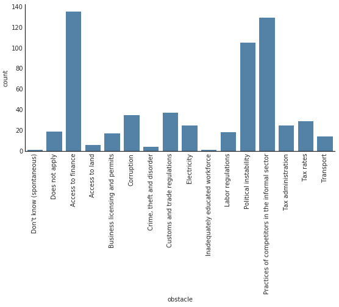

```python
with sns.axes_style('white'):
    g = sns.factorplot("obstacle", data=zim_df, aspect=2,
                       kind="count", color='steelblue')
    g.set_xticklabels(rotation=90)
```